# Sistemos ggplot2 pagrindai

Statistinės transformacijos

```r
library(tidyverse)
knitr::opts_chunk$set(fig.height = 3, fig.width = 6)
Sys.setlocale(locale = "Lithuanian")
```

```
[1] "LC_COLLATE=Lithuanian_Lithuania.1257;LC_CTYPE=Lithuanian_Lithuania.1257;LC_MONETARY=Lithuanian_Lithuania.1257;LC_NUMERIC=C;LC_TIME=Lithuanian_Lithuania.1257"
```

# Grafikų elementų sluoksniai (ggplot2)

## ggplot2 elementų sluoksnai

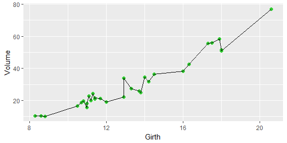

```r
ggplot(trees, aes(Girth, Volume)) +
    geom_point(color = "limegreen", size = 2) +
    geom_line()
```

Eilutes su geomais sukeiskite vietomis. Ką pastebite?

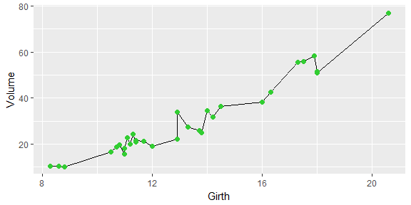

```r
ggplot(trees, aes(Girth, Volume)) +
    geom_line() +
    geom_point(color = "limegreen", size = 2)
```

# Statistinės transformacijos

## Duomenys: diamonds

```r
data(diamonds)
```

Patyrinėkite duomenis

```r
head(diamonds)
```

| carat | cut | color | clarity | depth | table | price | x | y | z |
| --- | --- | --- | --- | --- | --- | --- | --- | --- | --- |
| 0.23 | Ideal | E | SI2 | 61.5 | 55 | 326 | 3.95 | 3.98 | 2.43 |
| 0.21 | Premium | E | SI1 | 59.8 | 61 | 326 | 3.89 | 3.84 | 2.31 |
| 0.23 | Good | E | VS1 | 56.9 | 65 | 327 | 4.05 | 4.07 | 2.31 |
| 0.29 | Premium | I | VS2 | 62.4 | 58 | 334 | 4.20 | 4.23 | 2.63 |
| 0.31 | Good | J | SI2 | 63.3 | 58 | 335 | 4.34 | 4.35 | 2.75 |
| 0.24 | Very Good | J | VVS2 | 62.8 | 57 | 336 | 3.94 | 3.96 | 2.48 |

```r
tail(diamonds)
```

| carat | cut | color | clarity | depth | table | price | x | y | z |
| --- | --- | --- | --- | --- | --- | --- | --- | --- | --- |
| 0.72 | Premium | D | SI1 | 62.7 | 59 | 2757 | 5.69 | 5.73 | 3.58 |
| 0.72 | Ideal | D | SI1 | 60.8 | 57 | 2757 | 5.75 | 5.76 | 3.50 |
| 0.72 | Good | D | SI1 | 63.1 | 55 | 2757 | 5.69 | 5.75 | 3.61 |
| 0.70 | Very Good | D | SI1 | 62.8 | 60 | 2757 | 5.66 | 5.68 | 3.56 |
| 0.86 | Premium | H | SI2 | 61.0 | 58 | 2757 | 6.15 | 6.12 | 3.74 |
| 0.75 | Ideal | D | SI2 | 62.2 | 55 | 2757 | 5.83 | 5.87 | 3.64 |

```r
str(diamonds)
```

```
Classes ‘tbl_df’, ‘tbl’ and 'data.frame':   53940 obs. of  10 variables:
 $ carat  : num  0.23 0.21 0.23 0.29 0.31 0.24 0.24 0.26 0.22 0.23 ...
 $ cut    : Ord.factor w/ 5 levels "Fair"<"Good"<..: 5 4 2 4 2 3 3 3 1 3 ...
 $ color  : Ord.factor w/ 7 levels "D"<"E"<"F"<"G"<..: 2 2 2 6 7 7 6 5 2 5 ...
 $ clarity: Ord.factor w/ 8 levels "I1"<"SI2"<"SI1"<..: 2 3 5 4 2 6 7 3 4 5 ...
 $ depth  : num  61.5 59.8 56.9 62.4 63.3 62.8 62.3 61.9 65.1 59.4 ...
 $ table  : num  55 61 65 58 58 57 57 55 61 61 ...
 $ price  : int  326 326 327 334 335 336 336 337 337 338 ...
 $ x      : num  3.95 3.89 4.05 4.2 4.34 3.94 3.95 4.07 3.87 4 ...
 $ y      : num  3.98 3.84 4.07 4.23 4.35 3.96 3.98 4.11 3.78 4.05 ...
 $ z      : num  2.43 2.31 2.31 2.63 2.75 2.48 2.47 2.53 2.49 2.39 ...
```

```r
dplyr::glimpse(diamonds)
```

```
Observations: 53,940
Variables: 10
$ carat   <dbl> 0.23, 0.21, 0.23, 0.29, 0.31, 0.24, 0.24, 0.26, 0.22, 0.23, 0.30, 0.23, 0.22, 0.31, 0.20, 0.32, 0.30, 0.30, 0.30, 0.30, 0.30, 0.23, 0....
$ cut     <ord> Ideal, Premium, Good, Premium, Good, Very Good, Very Good, Very Good, Fair, Very Good, Good, Ideal, Premium, Ideal, Premium, Premium, ...
$ color   <ord> E, E, E, I, J, J, I, H, E, H, J, J, F, J, E, E, I, J, J, J, I, E, H, J, J, G, I, J, D, F, F, F, E, E, D, F, E, H, D, I, I, J, D, D, H,...
$ clarity <ord> SI2, SI1, VS1, VS2, SI2, VVS2, VVS1, SI1, VS2, VS1, SI1, VS1, SI1, SI2, SI2, I1, SI2, SI1, SI1, SI1, SI2, VS2, VS1, SI1, SI1, VVS2, VS...
$ depth   <dbl> 61.5, 59.8, 56.9, 62.4, 63.3, 62.8, 62.3, 61.9, 65.1, 59.4, 64.0, 62.8, 60.4, 62.2, 60.2, 60.9, 62.0, 63.4, 63.8, 62.7, 63.3, 63.8, 61...
$ table   <dbl> 55, 61, 65, 58, 58, 57, 57, 55, 61, 61, 55, 56, 61, 54, 62, 58, 54, 54, 56, 59, 56, 55, 57, 62, 62, 58, 57, 57, 61, 57, 57, 57, 59, 58...
$ price   <int> 326, 326, 327, 334, 335, 336, 336, 337, 337, 338, 339, 340, 342, 344, 345, 345, 348, 351, 351, 351, 351, 352, 353, 353, 353, 354, 355,...
$ x       <dbl> 3.95, 3.89, 4.05, 4.20, 4.34, 3.94, 3.95, 4.07, 3.87, 4.00, 4.25, 3.93, 3.88, 4.35, 3.79, 4.38, 4.31, 4.23, 4.23, 4.21, 4.26, 3.85, 3....
$ y       <dbl> 3.98, 3.84, 4.07, 4.23, 4.35, 3.96, 3.98, 4.11, 3.78, 4.05, 4.28, 3.90, 3.84, 4.37, 3.75, 4.42, 4.34, 4.29, 4.26, 4.27, 4.30, 3.92, 3....
$ z       <dbl> 2.43, 2.31, 2.31, 2.63, 2.75, 2.48, 2.47, 2.53, 2.49, 2.39, 2.73, 2.46, 2.33, 2.71, 2.27, 2.68, 2.68, 2.70, 2.71, 2.66, 2.71, 2.48, 2....
```

# 53940 stebejimu

# 10 kintamuju

# double, ordered factor, integer

## Paaiškinkite, kas nutiko?

Iš kur atsirado `y`?

```r
ggplot(data = diamonds) +
     geom_bar(mapping = aes(x = cut))
```

[output not shown]

## geom_bar(stat=“count”) vs. stat_count(geom=“bar”)

```r
ggplot(data = diamonds) +
     geom_bar(mapping = aes(x = cut))
```

```r
ggplot(data = diamonds) +
    stat_count(mapping = aes(x = cut))
```

## Galime modifikuoti transformacijos geomą

Atvaizduokite, ne stulpeliais, o taškais.

1. Pakeiskite geomą į `geom = "point"`

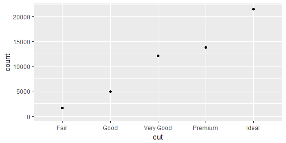

```r
ggplot(data = diamonds) +
    stat_count(mapping = aes(x = cut), geom = "point")
```

2. Turbūt jau žinote, ką daryti:

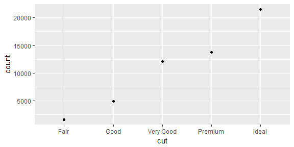

```r
ggplot(data = diamonds) +
    geom_point(mapping = aes(x = cut), stat = "count")
```

## Norite pakeisi numatytąją transformaciją

```r
demo_df <- tribble(
  ~cut,         ~freq,
  "Fair",       1610,
  "Good",       4906,
  "Very Good",  12082,
  "Premium",    13791,
  "Ideal",      21551
)
```

```r
glimpse(demo_df)
```

```
Observations: 5
Variables: 2
$ cut  <chr> "Fair", "Good", "Very Good", "Premium", "Ideal"
$ freq <dbl> 1610, 4906, 12082, 13791, 21551
```

```r
demo_df
```

| cut | freq |
| --- | --- |
| Fair | 1610 |
| Good | 4906 |
| Very Good | 12082 |
| Premium | 13791 |
| Ideal | 21551 |

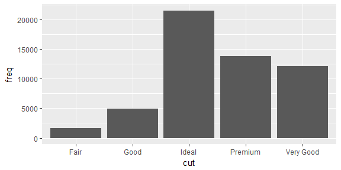

```r
ggplot(data = demo_df) +
  geom_bar(mapping = aes(x = cut, y = freq), stat = "identity")
```

```r
ggplot(data = demo_df) +
  geom_bar(mapping = aes(x = cut, y = freq), stat = "count")
```

```
Error: stat_count() must not be used with a y aesthetic.
```

## Norite pakeisti numatytąjį estetinį išdėstymą

```r
ggplot(data = diamonds) +
  geom_bar(mapping = aes(x = cut, y = ..count.., group = 1))
```

Panaikinkite `group` parametrą

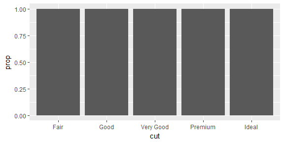

```r
ggplot(data = diamonds) +
  geom_bar(mapping = aes(x = cut, y = ..prop..))
```

## Norite pakeisti numatytąjį estetinį išdėstymą (2)

```r
c <- ggplot(mpg, aes(hwy))
```

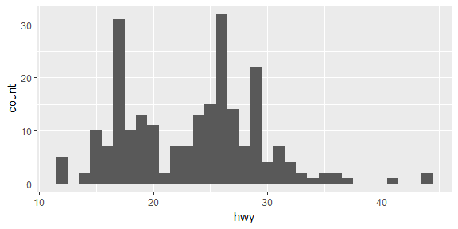

```r
c + stat_bin(binwidth = 1)
```

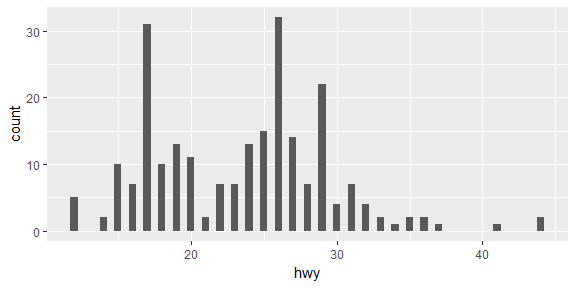

```r
c + stat_bin(binwidth = .5)
```

Išbandykite skirtingas parametro `y` reikšmes:

1. `..count..`
2. `..ncount..`
3. `..density..`
4. `..ndensity..`

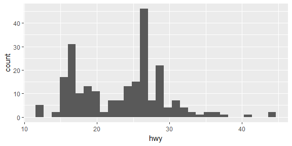

```r
c + stat_bin(aes(y = ..count..))
```

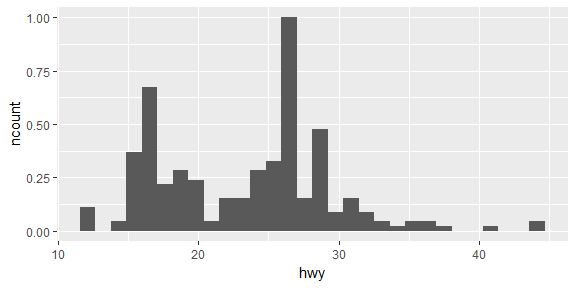

```r
c + stat_bin(aes(y = ..ncount..))
```

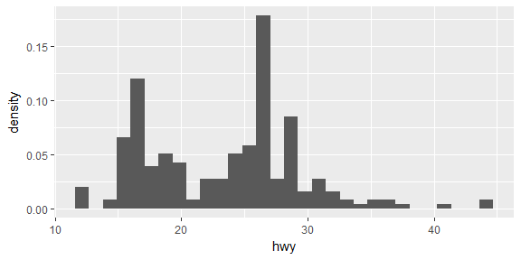

```r
c + stat_bin(aes(y = ..density..))
```

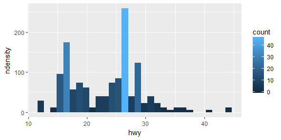

```r
c + stat_bin(aes(y = ..ndensity.., fill = ..count..))
```

## Norite atkreipti dėmesį į stat. transformacijas savo kode

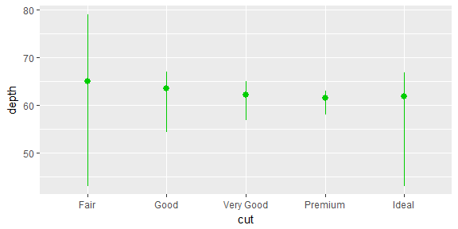

```r
ggplot(data = diamonds) +
   stat_summary(
      mapping = aes(x = cut, y = depth),
      fun.ymin = min,
      fun.ymax = max,
      fun.y = median,
      color = "green3"
   )
```

## Užduotys: statistinės transformacijos

1. Koks geomas pagal nutylėjimą naudojamas funkcijoje `stat_summary()`? #pointrange
2. Perrašykite kodą, kad jis naudotų `geom_` funkciją vietoje `stat_` funkcijos.

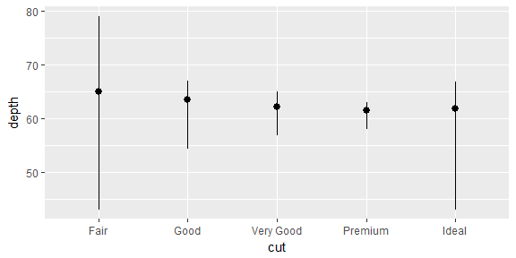

```r
# Pradinis kodas
ggplot(data = diamonds) +
   stat_summary(
      mapping = aes(x = cut, y = depth),
      fun.ymin = min,
      fun.ymax = max,
      fun.y = median
   )
```

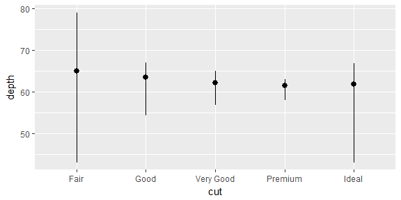

```r
# Pakeistas kodas
ggplot(data = diamonds) +
    geom_pointrange(aes(x = cut, y = depth),
        fun.ymin = min,
        fun.ymax = max,
        fun.y = median,
        stat = "summary" )
```

3. Ką atlieka funkcija `geom_col()`? Kuo ji skiriasi nuo `geom_bar()`? #Nubraizo stulpeline diagrama. Naudoja stat_identity kaip pagrindine stat reiksme, stulpeliu aukstis atspindi duomenu dydi.
4. Kokius papildomus kintamuosius apskaičiuoja `stat_smooth()`? Kokie parametrai kontroliuoja funkcijos elgesį? #y, ymin, ymax, se. method, formula, se, n, span, fullrange, level, method.args
5. Santykinių dažnių stulpelinėje diagramoje dažnai reikia estetinio išdėstymo parametro, pvz., `group = 1`? Kitaip sakant, kas negerai šiems dviems grafikams? Pataisykite juos.

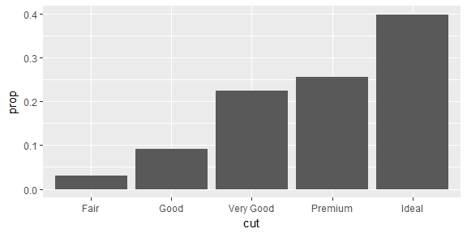

```r
ggplot(data = diamonds) +
  geom_bar(mapping = aes(x = cut, y = ..prop.., group = 1))
```

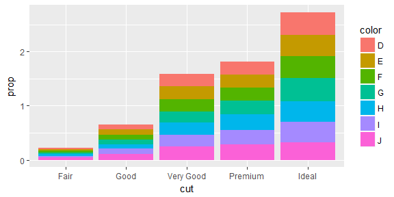

```r
ggplot(data = diamonds) +
  geom_bar(mapping = aes(x = cut, fill = color, y = ..prop.., group = color))
```

6. **(Papildoma).** Tam, kad veiktų darniai, dauguma geomų ir statistinių transformacijų yra naudojami numatytomis poromis (`geom` ir `stat`). Peržiūrėkite dokumentaciją ir sudarykite visų šių porų sąrašą. Ką jos turi bendro?